# Risk Factor Analysis

## Outcome Variable

**Outcome Variable:** ever_stunted

## Predictor Variables

**Intervention Variable:** birthwt

**Adjustment Set:**

unadjusted

## Stratifying Variables

The analysis was stratified on these variable(s):

- agecat
- studyid

The following strata were considered:

- agecat: 12 months, studyid: ki1000108-CMC-V-BCS-2002
- agecat: 12 months, studyid: ki1000108-IRC
- agecat: 12 months, studyid: ki1000109-EE
- agecat: 12 months, studyid: ki1000304b-SAS-CompFeed
- agecat: 12 months, studyid: ki1017093c-NIH-Crypto
- agecat: 12 months, studyid: ki1066203-TanzaniaChild2
- agecat: 12 months, studyid: ki1101329-Keneba
- agecat: 12 months, studyid: ki1119695-PROBIT
- agecat: 12 months, studyid: ki1126311-ZVITAMBO
- agecat: 12 months, studyid: ki1135781-COHORTS
- agecat: 12 months, studyid: kiGH5241-JiVitA-3
- agecat: 12 months, studyid: kiGH5241-JiVitA-4
- agecat: 18 months, studyid: ki1000108-CMC-V-BCS-2002
- agecat: 18 months, studyid: ki1000108-IRC
- agecat: 18 months, studyid: ki1000109-EE
- agecat: 18 months, studyid: ki1000304b-SAS-CompFeed
- agecat: 18 months, studyid: ki1017093c-NIH-Crypto
- agecat: 18 months, studyid: ki1066203-TanzaniaChild2
- agecat: 18 months, studyid: ki1101329-Keneba
- agecat: 18 months, studyid: ki1119695-PROBIT
- agecat: 18 months, studyid: ki1126311-ZVITAMBO
- agecat: 18 months, studyid: ki1135781-COHORTS
- agecat: 18 months, studyid: kiGH5241-JiVitA-3
- agecat: 18 months, studyid: kiGH5241-JiVitA-4
- agecat: 24 months, studyid: ki1000108-CMC-V-BCS-2002
- agecat: 24 months, studyid: ki1000108-IRC
- agecat: 24 months, studyid: ki1000109-EE
- agecat: 24 months, studyid: ki1000304b-SAS-CompFeed
- agecat: 24 months, studyid: ki1017093c-NIH-Crypto
- agecat: 24 months, studyid: ki1066203-TanzaniaChild2
- agecat: 24 months, studyid: ki1101329-Keneba
- agecat: 24 months, studyid: ki1119695-PROBIT
- agecat: 24 months, studyid: ki1126311-ZVITAMBO
- agecat: 24 months, studyid: ki1135781-COHORTS
- agecat: 24 months, studyid: kiGH5241-JiVitA-3
- agecat: 24 months, studyid: kiGH5241-JiVitA-4
- agecat: 3 months, studyid: ki1000108-CMC-V-BCS-2002
- agecat: 3 months, studyid: ki1000108-IRC
- agecat: 3 months, studyid: ki1000109-EE
- agecat: 3 months, studyid: ki1000304b-SAS-CompFeed
- agecat: 3 months, studyid: ki1017093c-NIH-Crypto
- agecat: 3 months, studyid: ki1066203-TanzaniaChild2
- agecat: 3 months, studyid: ki1101329-Keneba
- agecat: 3 months, studyid: ki1119695-PROBIT
- agecat: 3 months, studyid: ki1126311-ZVITAMBO
- agecat: 3 months, studyid: ki1135781-COHORTS
- agecat: 3 months, studyid: kiGH5241-JiVitA-3
- agecat: 3 months, studyid: kiGH5241-JiVitA-4
- agecat: 6 months, studyid: ki1000108-CMC-V-BCS-2002
- agecat: 6 months, studyid: ki1000108-IRC
- agecat: 6 months, studyid: ki1000109-EE
- agecat: 6 months, studyid: ki1000304b-SAS-CompFeed
- agecat: 6 months, studyid: ki1017093c-NIH-Crypto
- agecat: 6 months, studyid: ki1066203-TanzaniaChild2
- agecat: 6 months, studyid: ki1101329-Keneba
- agecat: 6 months, studyid: ki1119695-PROBIT
- agecat: 6 months, studyid: ki1126311-ZVITAMBO
- agecat: 6 months, studyid: ki1135781-COHORTS
- agecat: 6 months, studyid: kiGH5241-JiVitA-3
- agecat: 6 months, studyid: kiGH5241-JiVitA-4

### Dropped Strata

Some strata were dropped due to rare outcomes:

- agecat: 24 months, studyid: ki1000108-CMC-V-BCS-2002
- agecat: 24 months, studyid: ki1000109-EE
- agecat: 24 months, studyid: ki1000304b-SAS-CompFeed
- agecat: 24 months, studyid: kiGH5241-JiVitA-3
- agecat: 3 months, studyid: ki1017093c-NIH-Crypto
- agecat: 6 months, studyid: ki1017093c-NIH-Crypto

## Methods Detail

# Results Detail

## Results Plots

[figure not shown]

[figure not shown]

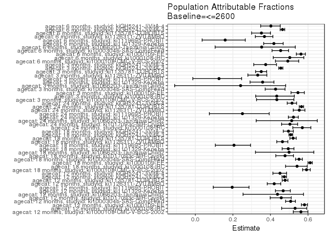

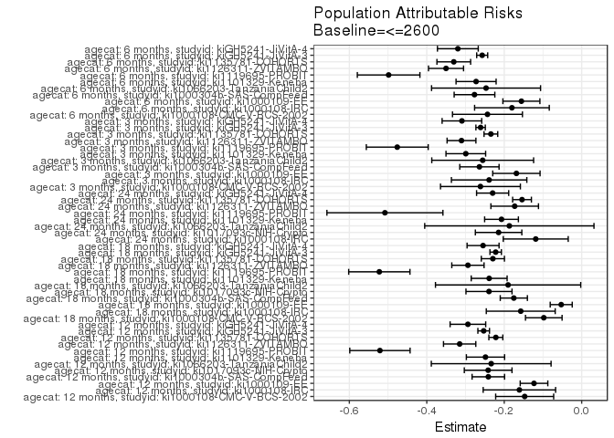

## Data Summary

| agecat | studyid | A | n | nA | nAY0 | nAY1 |
| --- | --- | --- | --- | --- | --- | --- |
| 12 months | ki1000108-CMC-V-BCS-2002 | <=2600 | 372 | 91 | 14 | 77 |
| 12 months | ki1000108-CMC-V-BCS-2002 | >3310 | 372 | 64 | 28 | 36 |
| 12 months | ki1000108-CMC-V-BCS-2002 | 2600-2970 | 372 | 84 | 24 | 60 |
| 12 months | ki1000108-CMC-V-BCS-2002 | 2970-3310 | 372 | 133 | 46 | 87 |
| 12 months | ki1000108-IRC | <=2600 | 402 | 101 | 34 | 67 |
| 12 months | ki1000108-IRC | >3310 | 402 | 60 | 46 | 14 |
| 12 months | ki1000108-IRC | 2600-2970 | 402 | 124 | 49 | 75 |
| 12 months | ki1000108-IRC | 2970-3310 | 402 | 117 | 71 | 46 |
| 12 months | ki1000109-EE | <=2600 | 373 | 176 | 9 | 167 |
| 12 months | ki1000109-EE | >3310 | 373 | 34 | 18 | 16 |
| 12 months | ki1000109-EE | 2600-2970 | 373 | 94 | 22 | 72 |
| 12 months | ki1000109-EE | 2970-3310 | 373 | 69 | 16 | 53 |
| 12 months | ki1000304b-SAS-CompFeed | <=2600 | 887 | 351 | 61 | 290 |
| 12 months | ki1000304b-SAS-CompFeed | >3310 | 887 | 78 | 53 | 25 |
| 12 months | ki1000304b-SAS-CompFeed | 2600-2970 | 887 | 252 | 121 | 131 |
| 12 months | ki1000304b-SAS-CompFeed | 2970-3310 | 887 | 206 | 133 | 73 |
| 12 months | ki1017093c-NIH-Crypto | <=2600 | 729 | 251 | 95 | 156 |
| 12 months | ki1017093c-NIH-Crypto | >3310 | 729 | 84 | 74 | 10 |
| 12 months | ki1017093c-NIH-Crypto | 2600-2970 | 729 | 222 | 147 | 75 |
| 12 months | ki1017093c-NIH-Crypto | 2970-3310 | 729 | 172 | 136 | 36 |
| 12 months | ki1066203-TanzaniaChild2 | <=2600 | 490 | 40 | 18 | 22 |
| 12 months | ki1066203-TanzaniaChild2 | >3310 | 490 | 200 | 158 | 42 |
| 12 months | ki1066203-TanzaniaChild2 | 2600-2970 | 490 | 56 | 29 | 27 |
| 12 months | ki1066203-TanzaniaChild2 | 2970-3310 | 490 | 194 | 130 | 64 |
| 12 months | ki1101329-Keneba | <=2600 | 1885 | 354 | 116 | 238 |
| 12 months | ki1101329-Keneba | >3310 | 1885 | 341 | 256 | 85 |
| 12 months | ki1101329-Keneba | 2600-2970 | 1885 | 586 | 301 | 285 |
| 12 months | ki1101329-Keneba | 2970-3310 | 1885 | 604 | 413 | 191 |
| 12 months | ki1119695-PROBIT | <=2600 | 7943 | 141 | 47 | 94 |
| 12 months | ki1119695-PROBIT | >3310 | 7943 | 4723 | 4430 | 293 |

[output cut: 210 more lines]

## Results Table

### Parameter: TSM

| agecat | studyid | intervention_level | baseline_level | estimate | ci_lower | ci_upper |
| --- | --- | --- | --- | --- | --- | --- |
| 12 months | ki1000108-CMC-V-BCS-2002 | <=2600 | NA | 0.8461538 | 0.7719238 | 0.9203839 |
| 12 months | ki1000108-CMC-V-BCS-2002 | >3310 | NA | 0.5625000 | 0.4407993 | 0.6842007 |
| 12 months | ki1000108-CMC-V-BCS-2002 | 2600-2970 | NA | 0.7142857 | 0.6175482 | 0.8110232 |
| 12 months | ki1000108-CMC-V-BCS-2002 | 2970-3310 | NA | 0.6541353 | 0.5731897 | 0.7350810 |
| 12 months | ki1000108-IRC | <=2600 | NA | 0.6633663 | 0.5710914 | 0.7556413 |
| 12 months | ki1000108-IRC | >3310 | NA | 0.2333333 | 0.1261802 | 0.3404865 |
| 12 months | ki1000108-IRC | 2600-2970 | NA | 0.6048387 | 0.5186828 | 0.6909946 |
| 12 months | ki1000108-IRC | 2970-3310 | NA | 0.3931624 | 0.3045452 | 0.4817796 |
| 12 months | ki1000109-EE | <=2600 | NA | 0.9488636 | 0.9162769 | 0.9814504 |
| 12 months | ki1000109-EE | >3310 | NA | 0.4705882 | 0.3025884 | 0.6385881 |
| 12 months | ki1000109-EE | 2600-2970 | NA | 0.7659574 | 0.6802503 | 0.8516646 |
| 12 months | ki1000109-EE | 2970-3310 | NA | 0.7681159 | 0.6684021 | 0.8678298 |
| 12 months | ki1000304b-SAS-CompFeed | <=2600 | NA | 0.8262108 | 0.7865468 | 0.8658748 |
| 12 months | ki1000304b-SAS-CompFeed | >3310 | NA | 0.3205128 | 0.2168891 | 0.4241365 |
| 12 months | ki1000304b-SAS-CompFeed | 2600-2970 | NA | 0.5198413 | 0.4581220 | 0.5815605 |
| 12 months | ki1000304b-SAS-CompFeed | 2970-3310 | NA | 0.3543689 | 0.2890138 | 0.4197240 |
| 12 months | ki1017093c-NIH-Crypto | <=2600 | NA | 0.6215139 | 0.5614713 | 0.6815566 |
| 12 months | ki1017093c-NIH-Crypto | >3310 | NA | 0.1190476 | 0.0497460 | 0.1883492 |
| 12 months | ki1017093c-NIH-Crypto | 2600-2970 | NA | 0.3378378 | 0.2755783 | 0.4000974 |
| 12 months | ki1017093c-NIH-Crypto | 2970-3310 | NA | 0.2093023 | 0.1484644 | 0.2701402 |
| 12 months | ki1066203-TanzaniaChild2 | <=2600 | NA | 0.5500000 | 0.3956704 | 0.7043296 |
| 12 months | ki1066203-TanzaniaChild2 | >3310 | NA | 0.2100000 | 0.1534933 | 0.2665067 |
| 12 months | ki1066203-TanzaniaChild2 | 2600-2970 | NA | 0.4821429 | 0.3511371 | 0.6131487 |
| 12 months | ki1066203-TanzaniaChild2 | 2970-3310 | NA | 0.3298969 | 0.2636675 | 0.3961263 |
| 12 months | ki1101329-Keneba | <=2600 | NA | 0.6723164 | 0.6234088 | 0.7212239 |
| 12 months | ki1101329-Keneba | >3310 | NA | 0.2492669 | 0.2033406 | 0.2951931 |
| 12 months | ki1101329-Keneba | 2600-2970 | NA | 0.4863481 | 0.4458698 | 0.5268265 |
| 12 months | ki1101329-Keneba | 2970-3310 | NA | 0.3162252 | 0.2791315 | 0.3533188 |
| 12 months | ki1119695-PROBIT | <=2600 | NA | 0.6666667 | 0.5888523 | 0.7444810 |
| 12 months | ki1119695-PROBIT | >3310 | NA | 0.0620368 | 0.0551569 | 0.0689168 |

[output cut: 186 more lines]

### Parameter: E(Y)

| agecat | studyid | intervention_level | baseline_level | estimate | ci_lower | ci_upper |
| --- | --- | --- | --- | --- | --- | --- |
| 12 months | ki1000108-CMC-V-BCS-2002 | NA | NA | 0.6989247 | 0.6891249 | 0.7087246 |
| 12 months | ki1000108-IRC | NA | NA | 0.5024876 | 0.4873168 | 0.5176584 |
| 12 months | ki1000109-EE | NA | NA | 0.8257373 | 0.8113069 | 0.8401677 |
| 12 months | ki1000304b-SAS-CompFeed | NA | NA | 0.5851184 | 0.5715064 | 0.5987304 |
| 12 months | ki1017093c-NIH-Crypto | NA | NA | 0.3799726 | 0.3663157 | 0.3936294 |
| 12 months | ki1066203-TanzaniaChild2 | NA | NA | 0.3163265 | 0.3065019 | 0.3261512 |
| 12 months | ki1101329-Keneba | NA | NA | 0.4238727 | 0.4171700 | 0.4305754 |
| 12 months | ki1119695-PROBIT | NA | NA | 0.1456628 | 0.1428933 | 0.1484324 |
| 12 months | ki1126311-ZVITAMBO | NA | NA | 0.3770169 | 0.3701755 | 0.3838584 |
| 12 months | ki1135781-COHORTS | NA | NA | 0.4118646 | 0.4086304 | 0.4150988 |
| 12 months | kiGH5241-JiVitA-3 | NA | NA | 0.4526379 | 0.4473114 | 0.4579644 |
| 12 months | kiGH5241-JiVitA-4 | NA | NA | 0.4391489 | 0.4272146 | 0.4510833 |
| 18 months | ki1000108-CMC-V-BCS-2002 | NA | NA | 0.8471850 | 0.8414847 | 0.8528852 |
| 18 months | ki1000108-IRC | NA | NA | 0.5583127 | 0.5429339 | 0.5736914 |
| 18 months | ki1000109-EE | NA | NA | 0.9118457 | 0.9057557 | 0.9179358 |
| 18 months | ki1000304b-SAS-CompFeed | NA | NA | 0.7149533 | 0.7043405 | 0.7255661 |
| 18 months | ki1017093c-NIH-Crypto | NA | NA | 0.4433566 | 0.4295471 | 0.4571661 |
| 18 months | ki1066203-TanzaniaChild2 | NA | NA | 0.4253521 | 0.4149081 | 0.4357962 |
| 18 months | ki1101329-Keneba | NA | NA | 0.5140187 | 0.5072856 | 0.5207518 |
| 18 months | ki1119695-PROBIT | NA | NA | 0.1565217 | 0.1536484 | 0.1593951 |
| 18 months | ki1126311-ZVITAMBO | NA | NA | 0.4859763 | 0.4779618 | 0.4939907 |
| 18 months | ki1135781-COHORTS | NA | NA | 0.6370497 | 0.6325903 | 0.6415092 |
| 18 months | kiGH5241-JiVitA-3 | NA | NA | 0.5442587 | 0.5391643 | 0.5493531 |
| 18 months | kiGH5241-JiVitA-4 | NA | NA | 0.5533217 | 0.5426106 | 0.5640327 |
| 24 months | ki1000108-IRC | NA | NA | 0.6386139 | 0.6257591 | 0.6514687 |
| 24 months | ki1017093c-NIH-Crypto | NA | NA | 0.5015773 | 0.4879496 | 0.5152049 |
| 24 months | ki1066203-TanzaniaChild2 | NA | NA | 0.4798387 | 0.4675996 | 0.4920779 |
| 24 months | ki1101329-Keneba | NA | NA | 0.5864578 | 0.5799479 | 0.5929676 |
| 24 months | ki1119695-PROBIT | NA | NA | 0.2061657 | 0.2010544 | 0.2112770 |
| 24 months | ki1126311-ZVITAMBO | NA | NA | 0.7191489 | 0.7072292 | 0.7310687 |
| 24 months | ki1135781-COHORTS | NA | NA | 0.7663255 | 0.7628840 | 0.7697670 |
| 24 months | kiGH5241-JiVitA-4 | NA | NA | 0.6003976 | 0.5900298 | 0.6107654 |
| 3 months | ki1000108-CMC-V-BCS-2002 | NA | NA | 0.3453039 | 0.3277301 | 0.3628776 |
| 3 months | ki1000108-IRC | NA | NA | 0.3143564 | 0.2989601 | 0.3297528 |
| 3 months | ki1000109-EE | NA | NA | 0.6358839 | 0.6172493 | 0.6545186 |
| 3 months | ki1000304b-SAS-CompFeed | NA | NA | 0.3323045 | 0.3183201 | 0.3462889 |
| 3 months | ki1066203-TanzaniaChild2 | NA | NA | 0.0973154 | 0.0895735 | 0.1050573 |
| 3 months | ki1101329-Keneba | NA | NA | 0.2383933 | 0.2312216 | 0.2455651 |
| 3 months | ki1119695-PROBIT | NA | NA | 0.0740923 | 0.0719280 | 0.0762566 |
| 3 months | ki1126311-ZVITAMBO | NA | NA | 0.2100744 | 0.2045123 | 0.2156365 |
| 3 months | ki1135781-COHORTS | NA | NA | 0.1784475 | 0.1753544 | 0.1815406 |
| 3 months | kiGH5241-JiVitA-3 | NA | NA | 0.4035969 | 0.3991016 | 0.4080921 |
| 3 months | kiGH5241-JiVitA-4 | NA | NA | 0.2733564 | 0.2607022 | 0.2860106 |
| 6 months | ki1000108-CMC-V-BCS-2002 | NA | NA | 0.5122616 | 0.4964094 | 0.5281138 |
| 6 months | ki1000108-IRC | NA | NA | 0.4179104 | 0.4031695 | 0.4326514 |
| 6 months | ki1000109-EE | NA | NA | 0.7426273 | 0.7254452 | 0.7598095 |
| 6 months | ki1000304b-SAS-CompFeed | NA | NA | 0.4250310 | 0.4089454 | 0.4411166 |
| 6 months | ki1066203-TanzaniaChild2 | NA | NA | 0.1905626 | 0.1817270 | 0.1993982 |
| 6 months | ki1101329-Keneba | NA | NA | 0.3221918 | 0.3149370 | 0.3294465 |
| 6 months | ki1119695-PROBIT | NA | NA | 0.1042654 | 0.1017365 | 0.1067943 |
| 6 months | ki1126311-ZVITAMBO | NA | NA | 0.2967515 | 0.2888877 | 0.3046154 |
| 6 months | ki1135781-COHORTS | NA | NA | 0.2530287 | 0.2468904 | 0.2591671 |
| 6 months | kiGH5241-JiVitA-3 | NA | NA | 0.4257384 | 0.4206108 | 0.4308661 |
| 6 months | kiGH5241-JiVitA-4 | NA | NA | 0.3388834 | 0.3251749 | 0.3525920 |

### Parameter: RR

| agecat | studyid | intervention_level | baseline_level | estimate | ci_lower | ci_upper |
| --- | --- | --- | --- | --- | --- | --- |
| 12 months | ki1000108-CMC-V-BCS-2002 | >3310 | <=2600 | 1.944049 | 1.5392683 | 2.455274 |
| 12 months | ki1000108-CMC-V-BCS-2002 | 2600-2970 | <=2600 | 2.326014 | 1.9793989 | 2.733324 |
| 12 months | ki1000108-CMC-V-BCS-2002 | 2970-3310 | <=2600 | 2.166405 | 1.8615008 | 2.521251 |
| 12 months | ki1000108-IRC | >3310 | <=2600 | 1.421541 | 0.8797731 | 2.296931 |
| 12 months | ki1000108-IRC | 2600-2970 | <=2600 | 2.488728 | 2.0394396 | 3.036995 |
| 12 months | ki1000108-IRC | 2970-3310 | <=2600 | 1.808825 | 1.3879315 | 2.357356 |
| 12 months | ki1000109-EE | >3310 | <=2600 | 1.642056 | 1.1471740 | 2.350427 |
| 12 months | ki1000109-EE | 2600-2970 | <=2600 | 2.241705 | 1.9940934 | 2.520062 |
| 12 months | ki1000109-EE | 2970-3310 | <=2600 | 2.246810 | 1.9644836 | 2.569711 |
| 12 months | ki1000304b-SAS-CompFeed | >3310 | <=2600 | 1.473928 | 1.0629843 | 2.043741 |
| 12 months | ki1000304b-SAS-CompFeed | 2600-2970 | <=2600 | 1.876085 | 1.6505715 | 2.132410 |
| 12 months | ki1000304b-SAS-CompFeed | 2970-3310 | <=2600 | 1.535581 | 1.2691356 | 1.857964 |
| 12 months | ki1017093c-NIH-Crypto | >3310 | <=2600 | 1.211119 | 0.6712925 | 2.185052 |
| 12 months | ki1017093c-NIH-Crypto | 2600-2970 | <=2600 | 1.722148 | 1.3986363 | 2.120490 |
| 12 months | ki1017093c-NIH-Crypto | 2970-3310 | <=2600 | 1.400406 | 1.0309270 | 1.902304 |
| 12 months | ki1066203-TanzaniaChild2 | >3310 | <=2600 | 1.464946 | 0.9930753 | 2.161030 |
| 12 months | ki1066203-TanzaniaChild2 | 2600-2970 | <=2600 | 2.402773 | 1.6258441 | 3.550966 |
| 12 months | ki1066203-TanzaniaChild2 | 2970-3310 | <=2600 | 1.821777 | 1.2901923 | 2.572386 |
| 12 months | ki1101329-Keneba | >3310 | <=2600 | 1.448833 | 1.1884762 | 1.766225 |
| 12 months | ki1101329-Keneba | 2600-2970 | <=2600 | 2.061413 | 1.8456889 | 2.302351 |
| 12 months | ki1101329-Keneba | 2970-3310 | <=2600 | 1.600557 | 1.3942056 | 1.837450 |
| 12 months | ki1119695-PROBIT | >3310 | <=2600 | 1.097522 | 0.9343066 | 1.289251 |
| 12 months | ki1119695-PROBIT | 2600-2970 | <=2600 | 1.773708 | 1.5356249 | 2.048704 |
| 12 months | ki1119695-PROBIT | 2970-3310 | <=2600 | 1.346199 | 1.1659772 | 1.554277 |
| 12 months | ki1126311-ZVITAMBO | >3310 | <=2600 | 1.310287 | 1.0909196 | 1.573765 |
| 12 months | ki1126311-ZVITAMBO | 2600-2970 | <=2600 | 1.860754 | 1.6762078 | 2.065619 |
| 12 months | ki1126311-ZVITAMBO | 2970-3310 | <=2600 | 1.485833 | 1.3087841 | 1.686833 |
| 12 months | ki1135781-COHORTS | >3310 | <=2600 | 1.348044 | 1.1974232 | 1.517610 |
| 12 months | ki1135781-COHORTS | 2600-2970 | <=2600 | 1.893193 | 1.7930754 | 1.998902 |
| 12 months | ki1135781-COHORTS | 2970-3310 | <=2600 | 1.580629 | 1.4811840 | 1.686750 |

[output cut: 132 more lines]

### Parameter: PAR

| agecat | studyid | intervention_level | baseline_level | estimate | ci_lower | ci_upper |
| --- | --- | --- | --- | --- | --- | --- |
| 12 months | ki1000108-CMC-V-BCS-2002 | <=2600 | NA | -0.1472291 | -0.2221033 | -0.0723549 |
| 12 months | ki1000108-IRC | <=2600 | NA | -0.1608788 | -0.2543925 | -0.0673651 |
| 12 months | ki1000109-EE | <=2600 | NA | -0.1231264 | -0.1587653 | -0.0874874 |
| 12 months | ki1000304b-SAS-CompFeed | <=2600 | NA | -0.2410924 | -0.2830271 | -0.1991578 |
| 12 months | ki1017093c-NIH-Crypto | <=2600 | NA | -0.2415414 | -0.3031176 | -0.1799652 |
| 12 months | ki1066203-TanzaniaChild2 | <=2600 | NA | -0.2336735 | -0.3883155 | -0.0790314 |
| 12 months | ki1101329-Keneba | <=2600 | NA | -0.2484437 | -0.2978084 | -0.1990790 |
| 12 months | ki1119695-PROBIT | <=2600 | NA | -0.5210038 | -0.5988674 | -0.4431402 |
| 12 months | ki1126311-ZVITAMBO | <=2600 | NA | -0.3151318 | -0.3568290 | -0.2734346 |
| 12 months | ki1135781-COHORTS | <=2600 | NA | -0.2216802 | -0.2397009 | -0.2036594 |
| 12 months | kiGH5241-JiVitA-3 | <=2600 | NA | -0.2530849 | -0.2680910 | -0.2380787 |
| 12 months | kiGH5241-JiVitA-4 | <=2600 | NA | -0.2938354 | -0.3397949 | -0.2478758 |
| 18 months | ki1000108-CMC-V-BCS-2002 | <=2600 | NA | -0.0978700 | -0.1450969 | -0.0506430 |
| 18 months | ki1000108-IRC | <=2600 | NA | -0.1573736 | -0.2463617 | -0.0683855 |
| 18 months | ki1000109-EE | <=2600 | NA | -0.0528602 | -0.0812960 | -0.0244243 |
| 18 months | ki1000304b-SAS-CompFeed | <=2600 | NA | -0.1752544 | -0.2102980 | -0.1402109 |
| 18 months | ki1017093c-NIH-Crypto | <=2600 | NA | -0.2393743 | -0.2988481 | -0.1799005 |
| 18 months | ki1066203-TanzaniaChild2 | <=2600 | NA | -0.1900325 | -0.3775902 | -0.0024748 |
| 18 months | ki1101329-Keneba | <=2600 | NA | -0.2389225 | -0.2852715 | -0.1925735 |
| 18 months | ki1119695-PROBIT | <=2600 | NA | -0.5225827 | -0.6016800 | -0.4434854 |
| 18 months | ki1126311-ZVITAMBO | <=2600 | NA | -0.2937706 | -0.3354282 | -0.2521130 |
| 18 months | ki1135781-COHORTS | <=2600 | NA | -0.2293550 | -0.2592505 | -0.1994595 |
| 18 months | kiGH5241-JiVitA-3 | <=2600 | NA | -0.2221095 | -0.2368888 | -0.2073303 |
| 18 months | kiGH5241-JiVitA-4 | <=2600 | NA | -0.2546783 | -0.2959738 | -0.2133829 |
| 24 months | ki1000108-IRC | <=2600 | NA | -0.1186677 | -0.2025571 | -0.0347782 |
| 24 months | ki1017093c-NIH-Crypto | <=2600 | NA | -0.2145799 | -0.2745886 | -0.1545712 |
| 24 months | ki1066203-TanzaniaChild2 | <=2600 | NA | -0.1868280 | -0.4053851 | 0.0317292 |
| 24 months | ki1101329-Keneba | <=2600 | NA | -0.2070526 | -0.2506432 | -0.1634620 |
| 24 months | ki1119695-PROBIT | <=2600 | NA | -0.5081200 | -0.6579068 | -0.3583332 |
| 24 months | ki1126311-ZVITAMBO | <=2600 | NA | -0.1730079 | -0.2344353 | -0.1115806 |
| 24 months | ki1135781-COHORTS | <=2600 | NA | -0.1540827 | -0.1782976 | -0.1298678 |
| 24 months | kiGH5241-JiVitA-4 | <=2600 | NA | -0.2299595 | -0.2714274 | -0.1884917 |
| 3 months | ki1000108-CMC-V-BCS-2002 | <=2600 | NA | -0.2614377 | -0.3645696 | -0.1583058 |
| 3 months | ki1000108-IRC | <=2600 | NA | -0.2390416 | -0.3363941 | -0.1416891 |
| 3 months | ki1000109-EE | <=2600 | NA | -0.1685854 | -0.2296747 | -0.1074960 |
| 3 months | ki1000304b-SAS-CompFeed | <=2600 | NA | -0.2640965 | -0.3148414 | -0.2133516 |
| 3 months | ki1066203-TanzaniaChild2 | <=2600 | NA | -0.2556257 | -0.3871194 | -0.1241321 |
| 3 months | ki1101329-Keneba | <=2600 | NA | -0.2992411 | -0.3504248 | -0.2480574 |
| 3 months | ki1119695-PROBIT | <=2600 | NA | -0.4762433 | -0.5561529 | -0.3963336 |
| 3 months | ki1126311-ZVITAMBO | <=2600 | NA | -0.3103769 | -0.3475736 | -0.2731803 |
| 3 months | ki1135781-COHORTS | <=2600 | NA | -0.2344830 | -0.2521506 | -0.2168153 |
| 3 months | kiGH5241-JiVitA-3 | <=2600 | NA | -0.2610427 | -0.2731760 | -0.2489094 |
| 3 months | kiGH5241-JiVitA-4 | <=2600 | NA | -0.3093208 | -0.3604478 | -0.2581937 |
| 6 months | ki1000108-CMC-V-BCS-2002 | <=2600 | NA | -0.2432940 | -0.3336045 | -0.1529835 |
| 6 months | ki1000108-IRC | <=2600 | NA | -0.1801288 | -0.2765301 | -0.0837274 |
| 6 months | ki1000109-EE | <=2600 | NA | -0.1556777 | -0.2034606 | -0.1078948 |
| 6 months | ki1000304b-SAS-CompFeed | <=2600 | NA | -0.2768324 | -0.3293510 | -0.2243137 |
| 6 months | ki1066203-TanzaniaChild2 | <=2600 | NA | -0.2469374 | -0.3876813 | -0.1061934 |
| 6 months | ki1101329-Keneba | <=2600 | NA | -0.2727091 | -0.3244453 | -0.2209728 |
| 6 months | ki1119695-PROBIT | <=2600 | NA | -0.4985715 | -0.5793812 | -0.4177618 |
| 6 months | ki1126311-ZVITAMBO | <=2600 | NA | -0.3503073 | -0.3955569 | -0.3050577 |
| 6 months | ki1135781-COHORTS | <=2600 | NA | -0.3303046 | -0.3737888 | -0.2868204 |
| 6 months | kiGH5241-JiVitA-3 | <=2600 | NA | -0.2569316 | -0.2711282 | -0.2427350 |
| 6 months | kiGH5241-JiVitA-4 | <=2600 | NA | -0.3197992 | -0.3724888 | -0.2671096 |

### Parameter: PAF

| agecat | studyid | intervention_level | baseline_level | estimate | ci_lower | ci_upper |
| --- | --- | --- | --- | --- | --- | --- |
| 12 months | ki1000108-CMC-V-BCS-2002 | <=2600 | NA | 0.5622039 | 0.5215301 | 0.5994200 |
| 12 months | ki1000108-IRC | <=2600 | NA | 0.5311542 | 0.4594356 | 0.5933576 |
| 12 months | ki1000109-EE | <=2600 | NA | 0.5811482 | 0.5646933 | 0.5969811 |
| 12 months | ki1000304b-SAS-CompFeed | <=2600 | NA | 0.5074676 | 0.4804791 | 0.5330541 |
| 12 months | ki1017093c-NIH-Crypto | <=2600 | NA | 0.4573909 | 0.3984766 | 0.5105350 |
| 12 months | ki1066203-TanzaniaChild2 | <=2600 | NA | 0.4373734 | 0.2538482 | 0.5757584 |
| 12 months | ki1101329-Keneba | <=2600 | NA | 0.4676564 | 0.4265144 | 0.5058468 |
| 12 months | ki1119695-PROBIT | <=2600 | NA | 0.1962719 | 0.0953746 | 0.2859157 |
| 12 months | ki1126311-ZVITAMBO | <=2600 | NA | 0.4199872 | 0.3828046 | 0.4549297 |
| 12 months | ki1135781-COHORTS | <=2600 | NA | 0.4780041 | 0.4626105 | 0.4929567 |
| 12 months | kiGH5241-JiVitA-3 | <=2600 | NA | 0.4734358 | 0.4611301 | 0.4854605 |
| 12 months | kiGH5241-JiVitA-4 | <=2600 | NA | 0.4507077 | 0.4130142 | 0.4859808 |
| 18 months | ki1000108-CMC-V-BCS-2002 | <=2600 | NA | 0.5919803 | 0.5710343 | 0.6119036 |
| 18 months | ki1000108-IRC | <=2600 | NA | 0.5416435 | 0.4803397 | 0.5957154 |
| 18 months | ki1000109-EE | <=2600 | NA | 0.6114005 | 0.5997433 | 0.6227181 |
| 18 months | ki1000304b-SAS-CompFeed | <=2600 | NA | 0.5520756 | 0.5336338 | 0.5697882 |
| 18 months | ki1017093c-NIH-Crypto | <=2600 | NA | 0.4776342 | 0.4282838 | 0.5227246 |
| 18 months | ki1066203-TanzaniaChild2 | <=2600 | NA | 0.4990241 | 0.3201613 | 0.6308287 |
| 18 months | ki1101329-Keneba | <=2600 | NA | 0.4947395 | 0.4622622 | 0.5252553 |
| 18 months | ki1119695-PROBIT | <=2600 | NA | 0.2058497 | 0.1065347 | 0.2941252 |
| 18 months | ki1126311-ZVITAMBO | <=2600 | NA | 0.4638004 | 0.4335065 | 0.4924743 |
| 18 months | ki1135781-COHORTS | <=2600 | NA | 0.5206286 | 0.5036380 | 0.5370377 |
| 18 months | kiGH5241-JiVitA-3 | <=2600 | NA | 0.5084439 | 0.4983234 | 0.5183602 |
| 18 months | kiGH5241-JiVitA-4 | <=2600 | NA | 0.4958110 | 0.4683579 | 0.5218464 |
| 24 months | ki1000108-IRC | <=2600 | NA | 0.5697108 | 0.5190508 | 0.6150346 |
| 24 months | ki1017093c-NIH-Crypto | <=2600 | NA | 0.5036000 | 0.4590160 | 0.5445096 |
| 24 months | ki1066203-TanzaniaChild2 | <=2600 | NA | 0.5131300 | 0.3239204 | 0.6493868 |
| 24 months | ki1101329-Keneba | <=2600 | NA | 0.5224410 | 0.4952172 | 0.5481966 |
| 24 months | ki1119695-PROBIT | <=2600 | NA | 0.2507121 | 0.0746574 | 0.3932708 |
| 24 months | ki1126311-ZVITAMBO | <=2600 | NA | 0.5533942 | 0.5212282 | 0.5833992 |
| 24 months | ki1135781-COHORTS | <=2600 | NA | 0.5650800 | 0.5534335 | 0.5764227 |
| 24 months | kiGH5241-JiVitA-4 | <=2600 | NA | 0.5147347 | 0.4891682 | 0.5390216 |
| 3 months | ki1000108-CMC-V-BCS-2002 | <=2600 | NA | 0.4339721 | 0.3256861 | 0.5248688 |
| 3 months | ki1000108-IRC | <=2600 | NA | 0.4333693 | 0.3212966 | 0.5269358 |
| 3 months | ki1000109-EE | <=2600 | NA | 0.5463544 | 0.5095386 | 0.5804067 |
| 3 months | ki1000304b-SAS-CompFeed | <=2600 | NA | 0.4271796 | 0.3719912 | 0.4775181 |
| 3 months | ki1066203-TanzaniaChild2 | <=2600 | NA | 0.2409799 | -0.1102722 | 0.4811079 |
| 3 months | ki1101329-Keneba | <=2600 | NA | 0.3581570 | 0.2914005 | 0.4186244 |
| 3 months | ki1119695-PROBIT | <=2600 | NA | 0.1259618 | -0.0135179 | 0.2462463 |
| 3 months | ki1126311-ZVITAMBO | <=2600 | NA | 0.3321148 | 0.2797632 | 0.3806611 |
| 3 months | ki1135781-COHORTS | <=2600 | NA | 0.3508874 | 0.3206352 | 0.3797924 |
| 3 months | kiGH5241-JiVitA-3 | <=2600 | NA | 0.4551483 | 0.4439819 | 0.4660905 |
| 3 months | kiGH5241-JiVitA-4 | <=2600 | NA | 0.3744592 | 0.3108783 | 0.4321739 |
| 6 months | ki1000108-CMC-V-BCS-2002 | <=2600 | NA | 0.4923653 | 0.4266847 | 0.5505214 |
| 6 months | ki1000108-IRC | <=2600 | NA | 0.5028190 | 0.4147069 | 0.5776663 |
| 6 months | ki1000109-EE | <=2600 | NA | 0.5625087 | 0.5378826 | 0.5858224 |
| 6 months | ki1000304b-SAS-CompFeed | <=2600 | NA | 0.4542395 | 0.4083938 | 0.4965325 |
| 6 months | ki1066203-TanzaniaChild2 | <=2600 | NA | 0.3531053 | 0.1052180 | 0.5323187 |
| 6 months | ki1101329-Keneba | <=2600 | NA | 0.4181770 | 0.3640191 | 0.4677231 |
| 6 months | ki1119695-PROBIT | <=2600 | NA | 0.1588270 | 0.0361281 | 0.2659065 |
| 6 months | ki1126311-ZVITAMBO | <=2600 | NA | 0.3678421 | 0.3194312 | 0.4128093 |
| 6 months | ki1135781-COHORTS | <=2600 | NA | 0.3519345 | 0.2995838 | 0.4003725 |
| 6 months | kiGH5241-JiVitA-3 | <=2600 | NA | 0.4640086 | 0.4516324 | 0.4761055 |
| 6 months | kiGH5241-JiVitA-4 | <=2600 | NA | 0.4021926 | 0.3477303 | 0.4521075 |